# report

Anastasia Tatarentseva

2022-12-11

**Step 0.** Connected the necessary packages

```r
library(dplyr)
```

```r
library(ggplot2)
```

**Step 1.** All files from the folder olimpic_games_folder/data_folder were uploded and combined into one dataframe

```r
list.files(path = "https://github.com/anatatarentseva/BI_Stat_2022/tree/olimpic_games_branch/olimpic_games_folder/data_folder", pattern = "*.csv", full.names=TRUE)
```

```
## character(0)
```

```r
table_unified <- NULL
for (i in list.files()) {
  athlete_events <- read.csv(i)
  table_unified <- bind_rows(table_unified, athlete_events)
}
```

**Step 2.** The received dataframe was adjusted: 1) selected by age (the youngest participant in history is 10 years old, the oldest is 97 years old); 2) removed participants with unknown age; 3) removed the G sex; 4) made the upper limit on height (the tallest person in the world is 251 cm); 5) cut off the weight less than 20 kg; 6) deleted rows with an unknown year; 7) deleted rows with a non-three-character code; 8) deleted rows with the NA member number;

```r
table_modifided <- table_unified[!(table_unified$Age < 9|table_unified$Age > 98|is.na(table_unified$Age)|table_unified$Sex == "G"|table_unified$Height > 251|table_unified$Weight < 20|is.na(table_unified$Year)|table_unified$NOC == 'JP'|is.na(table_unified$ID)), ]
table_ok <- table_modifided[!is.na(table_modifided$ID), ]
```

**Step 3.** Found out the age of the youngest athletes of both sexes at the 1992 Olympics

**Answer: Female - 12; Male - 14**

```r
min(table_ok[table_ok$Year == 1992 & table_ok$Sex == 'M', ]$Age)
```

```
## [1] 14
```

```r
min(table_ok[table_ok$Year == 1992 & table_ok$Sex == 'F', ]$Age)
```

```
## [1] 12
```

**Step 4.** Calculated the average value and standard deviation of the Height variable for athletes of each sex

**Answer: Female mean - 167.8613; Male mean - 178.965; Female sd - 8.768035; Male sd - 9.367877**

```r
mean(table_ok[table_ok$Sex == 'M', ]$Height)
```

```
## [1] 178.965
```

```r
mean(table_ok[table_ok$Sex == 'F', ]$Height)
```

```
## [1] 167.8613
```

```r
sd(table_ok[table_ok$Sex == 'M', ]$Height)
```

```
## [1] 9.367877
```

```r
sd(table_ok[table_ok$Sex == 'F', ]$Height)
```

```
## [1] 8.768035
```

**Step 5.** Calculated the average value and standard deviation of the Height variable for female tennis players (sex = F) at the 2000 Olympics, rounded the answer to the first digit after the dot

**Answer: Mean - 171.8; sd - 6.5**

```r
round(mean(table_ok[table_ok$Sex == 'F' & table_ok$Year == 2000 & table_ok$Sport == 'Tennis', ]$Height), digits = 1)
```

```
## [1] 171.8
```

```r
round(sd(table_ok[table_ok$Sex == 'F' & table_ok$Year == 2000 & table_ok$Sport == 'Tennis', ]$Height), digits = 1)
```

```
## [1] 6.5
```

**Step 6.** Determined which sport the heaviest athlete participated in at the 2006 Olympics

**Answer: Skeleton**

```r
max(table_ok[table_ok$Sex == 'M' & table_ok$Year == 2006, ]$Weight)
```

```
## [1] 127
```

```r
table_ok[table_ok$Sex == 'M' & table_ok$Year == 2006 & table_ok$Weight == 127, ]$Sport
```

```
## [1] "Skeleton"
```

**Step 7.** Determined how many gold medals were received by women from 1980 to 2010

**Answer: 2167**

```r
table_woman <- table_ok[table_ok$Sex == 'F' & table_ok$Year >= 1980 & table_ok$Year <= 2010, ]$Medal
table(table_woman)[which(names(table(table_woman)) == 'Gold')]
```

```
## Gold
## 2167
```

**Step 8.** Determined how many times the athlete John Aalberg participated in the Olympic Games in different years

**Answer: 1992 - 4; 1994 - 4**

```r
table(table_ok[table_ok$Name == 'John Aalberg', ]$Year)
```

```
##
## 1992 1994
##    4    4
```

** Step 9.** Determined the least and most represented (by the number of participants) age groups of athletes at the 2008 Olympic Games. Possible age groups: [15-25), [25-35), [35-45), [45-55]

**Answer: Most represented group [25,35); least represented group [45,55]**

```r
table(cut(table_ok[table_ok$Year == 2008, ]$Age, breaks = c(15, 25, 35, 45, 55), right = FALSE, include.lowest = TRUE))
```

```
##
## [15,25) [25,35) [35,45) [45,55]
##    6170    6310     777     117
```

```r
result_vector <- table(cut(table_ok[table_ok$Year == 2008, ]$Age, breaks = c(15, 25, 35, 45, 55), right = FALSE, include.lowest = TRUE))
names(result_vector[which(result_vector == max(result_vector))])
```

```
## [1] "[25,35)"
```

```r
names(result_vector[which(result_vector == min(result_vector))])
```

```
## [1] "[45,55]"
```

**Step 10** Determined how much the number of sports at the 2002 Olympics has changed compared to The 1994 Olympics

**Answer: 3**

```r
numer_2002 <-length(unique(table_ok[table_ok$Year == 2002, ]$Sport))
numer_1994 <- length(unique(table_ok[table_ok$Year == 1994, ]$Sport))
numer_2002 - numer_1994
```

```
## [1] 3
```

**Step 11.** We have brought out the top 3 countries for each of the types of medals separately for the winter and summer Olympics

**Answer:** Winter: - GOLD (Canada, Soviet Union, United States), - SILVER (United States, Canada, Finland), - BRONZE (Finland, Sweden, United States); Summer: - GOLD (United States, Soviet Union, Germany), - SILVER (United States, Soviet Union, Australia), - BRONZE (United States, Soviet Union, Germany)

```r
gold_winter_table <- table_ok[table_ok$Season == 'Winter' & table_ok$Medal == 'Gold', ]
gold_winter <- sort(table(gold_winter_table$Team), decreasing = TRUE)
gold_winter[1:3]
```

```
##
##        Canada  Soviet Union United States
##           237           205           126
```

```r
silver_winter_table <- table_ok[table_ok$Season == 'Winter' & table_ok$Medal == 'Silver', ]
silver_winter <- sort(table(silver_winter_table$Team), decreasing = TRUE)
silver_winter[1:3]
```

```
##
## United States        Canada       Finland
##           228           174           137
```

```r
bronze_winter_table <- table_ok[table_ok$Season == 'Winter' & table_ok$Medal == 'Bronze', ]
bronze_winter <- sort(table(bronze_winter_table$Team), decreasing = TRUE)
bronze_winter[1:3]
```

```
##
##       Finland        Sweden United States
##           210           137           104
```

```r
gold_summer_table <- table_ok[table_ok$Season == 'Summer' & table_ok$Medal == 'Gold', ]
gold_summer <- sort(table(gold_summer_table$Team), decreasing = TRUE)
gold_summer[1:3]
```

```
##
## United States  Soviet Union       Germany
##          1949           756           400
```

```r
silver_summer_table <- table_ok[table_ok$Season == 'Summer' & table_ok$Medal == 'Silver', ]
silver_summer <- sort(table(silver_summer_table$Team), decreasing = TRUE)
silver_summer[1:3]
```

```
##
## United States  Soviet Union     Australia
##          1032           556           409
```

```r
bronze_summer_table <- table_ok[table_ok$Season == 'Summer' & table_ok$Medal == 'Bronze', ]
bronze_summer <- sort(table(bronze_summer_table$Team), decreasing = TRUE)
bronze_summer[1:3]
```

```
##
## United States  Soviet Union       Germany
##           834           552           484
```

**Step 12.** Created a new variable Height_z_scores and saved the values of the variable Height into it after its standardization

```r
Height_z_scores <- (table_ok$Height - mean(table_ok$Height))/sd(table_ok$Height)
```

**Step 13.** Created a new variable Height_min_max_scaled and save the values of the variable Height into it after applying min-max normalization to it

```r
Height_min_max_scaled <- (table_ok$Height - min(table_ok$Height))/(max(table_ok$Height) - min(table_ok$Height))
```

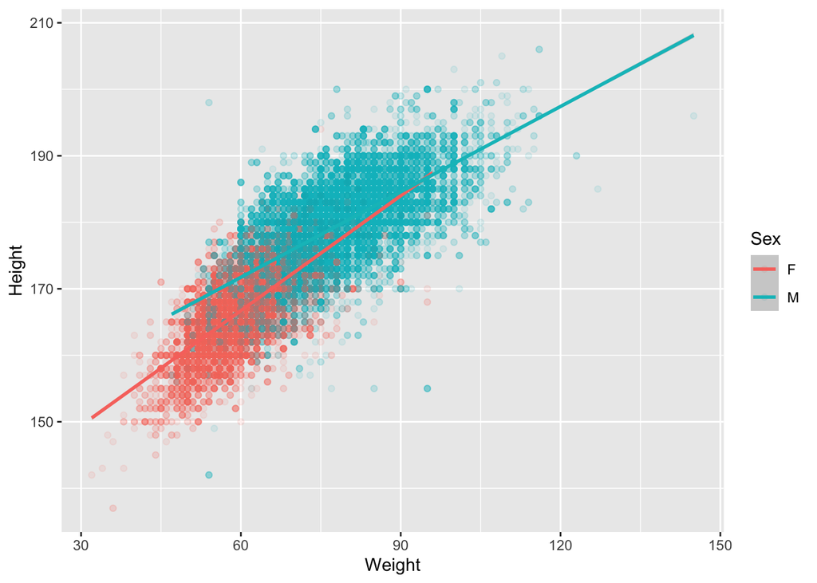

```r
table_winter <- table_ok[table_ok$Season == 'Winter', ]
ggplot(table_winter, aes(x = Weight, y = Height, color = Sex)) +
  geom_point(alpha = 0.1) +
  stat_smooth(method = lm)
```